# Pertemuan 4 - Pembangkitan ARMA

Keira Gisella

# Library

```r
library(TSA)
```

# PROSES MA(2): theta1 = 0.4, theta2 = 0.6, n = 300

```r
set.seed(1234)
n <- 300
wn <- rnorm(n)

theta1 <- 0.4
theta2 <- 0.6
```

## Pembangkitan manual

```r
ma2 <- wn[1:2]
for(i in 3:n){
  ma2[i] <- wn[i] + theta1*wn[i-1] + theta2*wn[i-2]
}
ma2
```

```
##   [1] -1.207065749  0.277429242  0.471173424 -1.745463687  0.141510314
##   [6] -0.729712854 -0.114842790 -0.472894305 -1.127948717 -1.443797742
##  [11] -1.171879031 -1.723286222 -1.461924092 -0.845074607  0.519525249
##  [16]  0.312187420  0.020572732 -1.181770516 -1.508255550  1.534249256
##  [21]  0.598119283  1.012450498 -0.556369299 -0.011041246 -0.774213194
##  [26] -1.449939345 -0.420758391 -1.662676381 -0.079747157 -1.556197355
##  [31]  0.718835126 -0.596243221 -0.238298741 -1.070389923 -2.255260716
##  [36] -2.120011486 -3.624543435 -2.913580609 -2.138714925 -1.388210999
##  [41]  1.086560934 -0.768382742 -0.413123964 -1.263954490 -1.619808057
##  [46] -1.534624150 -2.091327966 -2.276021753 -1.689013389 -1.457572736
##  [51] -2.319068111 -1.602598402 -2.425338748 -1.807763414 -1.233628102
##  [56] -0.110845196  1.775654086  0.223607057  2.285258743 -0.979456751
##  [61]  1.157010823  2.116941328  1.378789117  0.845856907 -0.296314421
##  [66]  1.372262398 -0.432336811  1.978634754  1.193531021  1.688995021
##  [71]  0.939220832 -0.250827924 -0.544575725  0.228395751  2.109671129
```

[output cut: 45 more lines]

## Pembangkitan dengan arima.sim

```r
set.seed(1234)
ma2.sim <- arima.sim(list(order=c(0,0,2), ma=c(theta1,theta2)), n=n)
ma2.sim
```

```
## Time Series:
## Start = 1
## End = 300
## Frequency = 1
##   [1]  0.471173424 -1.745463687  0.141510314 -0.729712854 -0.114842790
##   [6] -0.472894305 -1.127948717 -1.443797742 -1.171879031 -1.723286222
##  [11] -1.461924092 -0.845074607  0.519525249  0.312187420  0.020572732
##  [16] -1.181770516 -1.508255550  1.534249256  0.598119283  1.012450498
##  [21] -0.556369299 -0.011041246 -0.774213194 -1.449939345 -0.420758391
##  [26] -1.662676381 -0.079747157 -1.556197355  0.718835126 -0.596243221
##  [31] -0.238298741 -1.070389923 -2.255260716 -2.120011486 -3.624543435
##  [36] -2.913580609 -2.138714925 -1.388210999  1.086560934 -0.768382742
##  [41] -0.413123964 -1.263954490 -1.619808057 -1.534624150 -2.091327966
##  [46] -2.276021753 -1.689013389 -1.457572736 -2.319068111 -1.602598402
##  [51] -2.425338748 -1.807763414 -1.233628102 -0.110845196  1.775654086
```

[output cut: 49 more lines]

## Plot time series

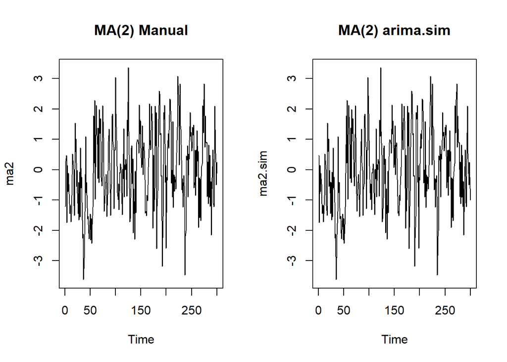

```r
par(mfrow = c(1, 2))
ts.plot(ma2, main = "MA(2) Manual")
ts.plot(ma2.sim, main = "MA(2) arima.sim")
```

```r
par(mfrow = c(1, 1))
```

## Plot ACF

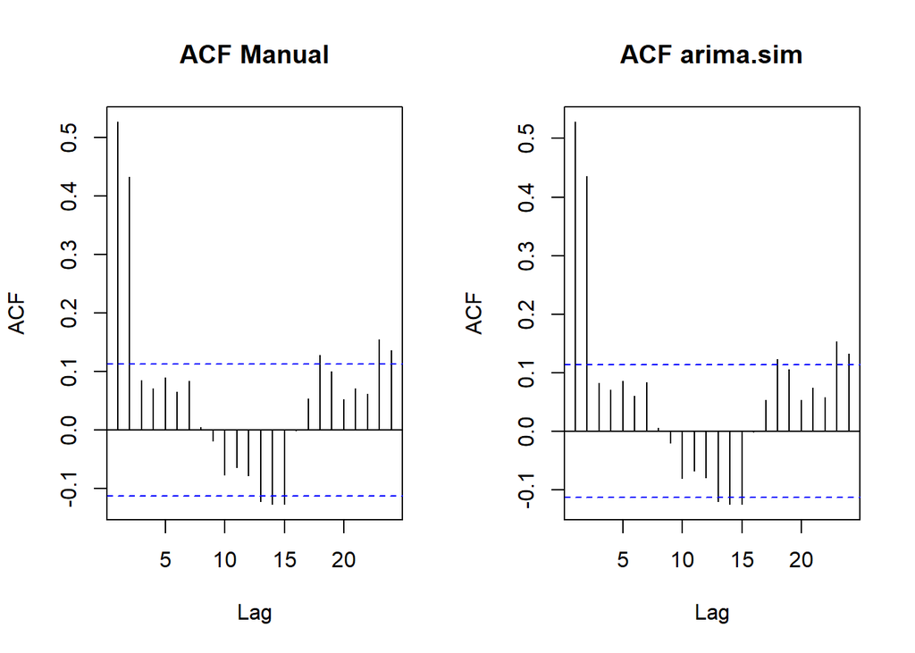

```r
par(mfrow = c(1, 2))
acf(ma2, main = "ACF Manual")
acf(ma2.sim, main = "ACF arima.sim")
```

```r
par(mfrow = c(1, 1))
```

**Interpretasi:** Berdasarkan plot ACF tersebut, terlihat bahwa ACF signifikan pada lag 1 dan 2, kemudian *cuts off* (berada dalam batas signifikansi) setelah lag 2. Pola ini sesuai dengan teori bahwa proses MA(2) memiliki ACF yang terputus setelah lag ke-q (q=2).

## Plot PACF

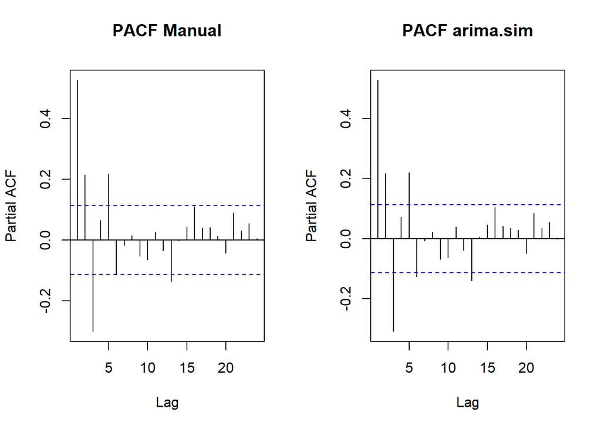

```r
par(mfrow = c(1, 2))
pacf(ma2, main = "PACF Manual")
pacf(ma2.sim, main = "PACF arima.sim")
```

```r
par(mfrow = c(1, 1))
```

**Interpretasi:** Berdasarkan plot PACF tersebut, terlihat bahwa PACF cenderung *tails off* (meluruh secara bergelombang) dan tidak terputus tegas di lag tertentu, sebagaimana ciri khas proses MA.

## Plot EACF

```r
TSA::eacf(ma2)
```

```
## AR/MA
##   0 1 2 3 4 5 6 7 8 9 10 11 12 13
## 0 x x o o o o o o o o o  o  x  x
## 1 x x x o o o o o o o o  o  o  o
## 2 x x x x o o o o o o o  o  o  o
## 3 x x x x x o o o o o o  o  o  o
## 4 x x x x x o o o o o o  o  o  o
## 5 x x x x x o x o o o o  o  o  o
## 6 x x x o x o o x o o o  o  o  o
## 7 x o x o x o o x o o o  o  o  o
```

```r
TSA::eacf(ma2.sim)
```

```
## AR/MA
##   0 1 2 3 4 5 6 7 8 9 10 11 12 13
## 0 x x o o o o o o o o o  o  x  x
## 1 x x x o o o o o o o o  o  o  o
## 2 x x x x o o o o o o o  o  o  o
## 3 x x x x o o o o o o o  o  o  o
## 4 x x x x o o o o o o o  o  o  o
## 5 x x o x x o x o o o o  o  o  o
## 6 o x o o x o o x o o o  o  o  o
## 7 x o x o x o o x o o o  o  o  o
```

**Interpretasi:** Berdasarkan pola segitiga nol pada plot EACF, segitiga nol mulai terbentuk pada ordo AR(0) dan MA(2), yang sesuai dengan model MA(2) yang dibangkitkan.

## Scatterplot Yt vs Yt-1

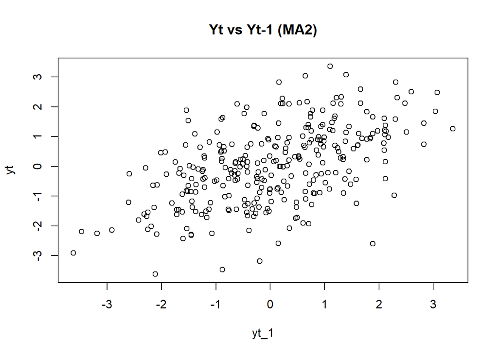

```r
yt   <- ma2[-1]
yt_1 <- ma2[-n]
plot(y = yt, x = yt_1, main = "Yt vs Yt-1 (MA2)")
```

```r
cor(yt, yt_1)
```

```
## [1] 0.5274606
```

**Interpretasi:** Berdasarkan scatterplot tersebut, terlihat bahwa terdapat hubungan positif antara $Y_t$ dengan $Y_{t-1}$ $(cor = 0.5275)$. Nilai ini cukup mendekati autokorelasi teoritis $\rho_1 = 0.4210$.

## Scatterplot Yt vs Yt-2

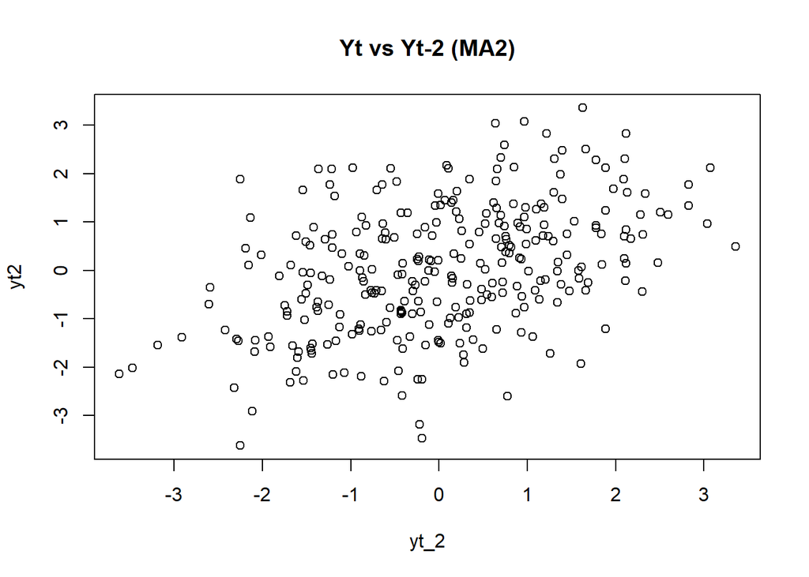

```r
yt2  <- ma2[-c(1,2)]
yt_2 <- ma2[-c(n-1, n)]
plot(y = yt2, x = yt_2, main = "Yt vs Yt-2 (MA2)")
```

```r
cor(yt2, yt_2)
```

```
## [1] 0.4339293
```

**Interpretasi:** Berdasarkan scatterplot tersebut, masih terlihat hubungan positif antara $Y_t$ dengan $Y_{t-2}$ meski lebih menyebar $(cor = 0.4339)$, mendekati nilai teoritis $\rho_2 = 0.3947.$

## Scatterplot Yt vs Yt-3

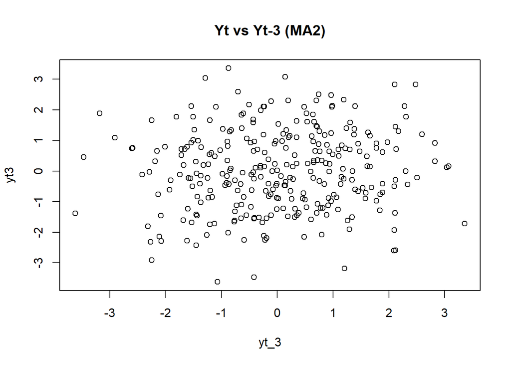

```r
yt3  <- ma2[-c(1,2,3)]
yt_3 <- ma2[-c(n-2, n-1, n)]
plot(y = yt3, x = yt_3, main = "Yt vs Yt-3 (MA2)")
```

```r
cor(yt3, yt_3)
```

```
## [1] 0.08555282
```

**Interpretasi:** Berdasarkan scatterplot tersebut, terlihat bahwa cenderung tidak ada hubungan antara $Y_t$ dengan $Y_{t-3}$ $(cor = 0.0856)$, mendekati nilai teoritis $\rho_3 = 0$. Hasil ini sesuai teori bahwa ACF proses MA(2) terputus (menjadi nol) setelah lag ke-2.

## Autokorelasi teoritis

```r
ARMAacf(ma = c(theta1, theta2), lag.max = 3)
```

```
##         0         1         2         3
## 1.0000000 0.4210526 0.3947368 0.0000000
```

# PROSES AR(2): phi1 = 0.5, phi2 = 0.2, n = 300

```r
set.seed(1234)
n <- 300
wn <- rnorm(n)

phi1 <- 0.5
phi2 <- 0.2
```

## Pembangkitan manual

```r
ar2 <- wn[1:2]
for(i in 3:n){
  ar2[i] <- phi1*ar2[i-1] + phi2*ar2[i-2] + wn[i]
}
ar2
```

```
##   [1] -1.207065749  0.277429242  0.981742648 -1.799340530 -0.274197047
##   [6]  0.009089263 -0.625034738 -0.857331372 -1.118124633 -1.620566420
##  [11] -1.511100836 -2.078050147 -2.117499135 -1.409900780 -0.168956158
##  [16] -0.476743729 -0.783172602 -1.398130464 -1.692871432  1.289773370
##  [21]  0.440400618 -0.012530914 -0.358733205  0.277716656 -0.626608560
##  [26] -1.705965859 -0.403548921 -1.566623355 -0.879159762 -1.688853153
##  [31]  0.082039017 -0.772344201 -1.079204335 -1.195329068 -2.442598870
##  [36] -2.627984511 -3.982551678 -3.857865933 -3.019737161 -2.747339308
##  [41] -0.528120821 -1.882170996 -1.902074296 -1.608094349 -2.178802110
##  [46] -2.379534243 -2.732845736 -3.094315602 -2.617555067 -2.424490611
##  [51] -3.541787576 -2.837867835 -3.236181057 -3.200626105 -2.409858787
##  [56] -1.281998796  0.524846317 -0.767330024  1.327213880 -0.647667612
##  [61]  0.598197434  2.718556265  1.444157230  0.596156288  0.579304834
##  [66]  2.185968123  0.070237292  1.840139450  2.263681974  1.836341674
##  [71]  1.377800070  0.600699632  0.209385897  0.873119442  2.548707762
```

[output cut: 45 more lines]

## Pembangkitan dengan arima.sim

```r
set.seed(1234)
ar2.sim <- arima.sim(list(order=c(2,0,0), ar=c(phi1,phi2)), n=n)
ar2.sim
```

```
## Time Series:
## Start = 1
## End = 300
## Frequency = 1
##   [1] -1.7066325607 -0.4040571790 -1.5670108246 -0.8794551485 -1.6890783403
##   [6]  0.0818673463 -0.7724750738 -1.0793041051 -1.1954051279 -2.4426568541
##  [11] -2.6280287147 -3.9825853771 -3.8578916236 -3.0197567460 -2.7473542381
##  [16] -0.5281322030 -1.8821796728 -1.9020809107 -1.6080993919 -2.1788059544
##  [21] -2.3795371734 -2.7328479702 -3.0943173054 -2.6175563658 -2.4244916012
##  [26] -3.5417883306 -2.8378684102 -3.2361814957 -3.2006264394 -2.4098590424
##  [31] -1.2819989901  0.5248461693 -0.7673301373  1.3272137941 -0.6476676781
##  [36]  0.5981973841  2.7185562271  1.4441572006  0.5961562661  0.5793048174
##  [41]  2.1859681101  0.0702372818  1.8401394423  2.2636819683  1.8363416698
##  [46]  1.3778000670  0.6006996293  0.2093858952  0.8731194410  2.5487077608
##  [51]  1.2955793561 -0.2331697165 -0.5810507641 -0.0788975632 -0.4727180494
```

[output cut: 49 more lines]

## Plot time series

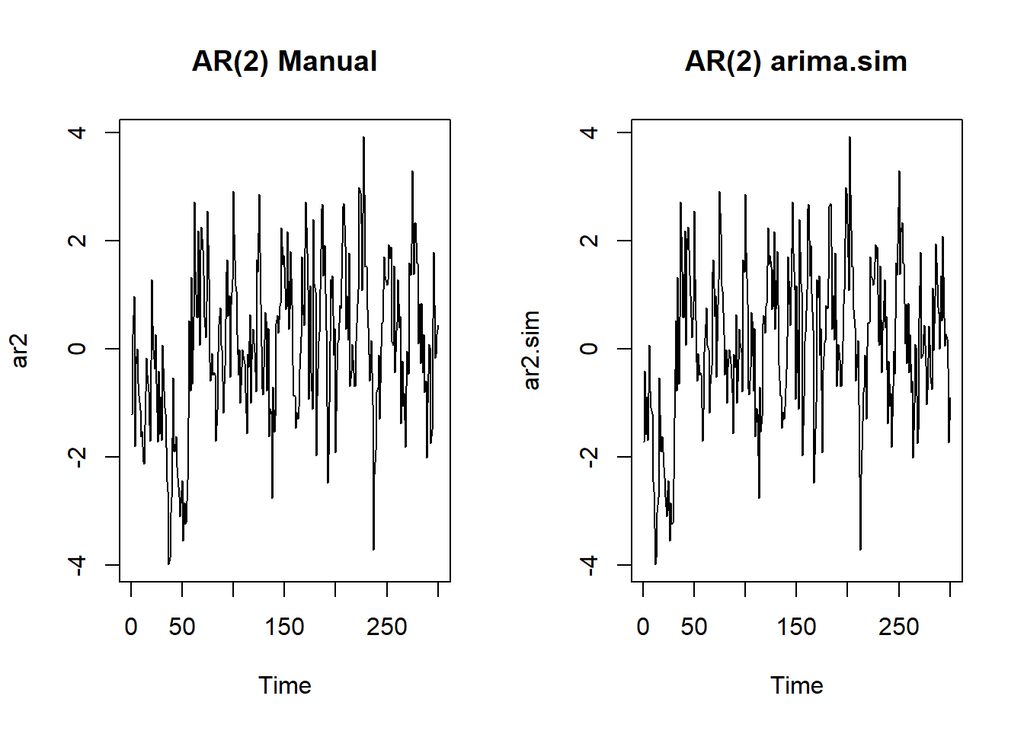

```r
par(mfrow = c(1, 2))
ts.plot(ar2, main = "AR(2) Manual")
ts.plot(ar2.sim, main = "AR(2) arima.sim")
```

```r
par(mfrow = c(1, 1))
```

**Interpretasi:** Berdasarkan plot time series, terlihat bahwa data AR(2) hasil pembangkitan manual maupun `arima.sim` berfluktuasi di sekitar rataan konstan tanpa tren naik/turun, sehingga data tersebut stasioner dalam rataan.

## Plot ACF

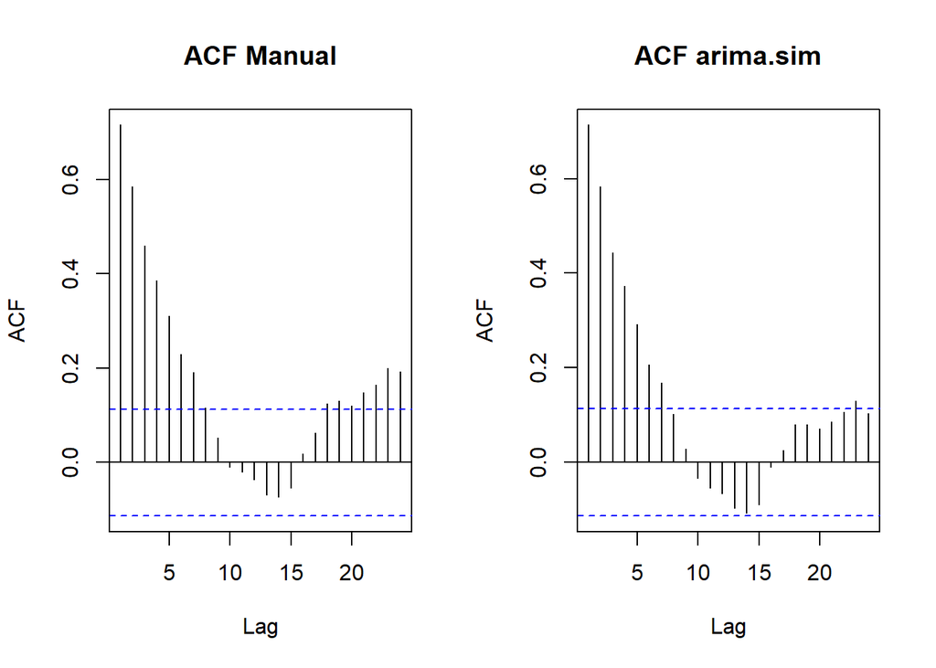

```r
par(mfrow = c(1, 2))
acf(ar2, main = "ACF Manual")
acf(ar2.sim, main = "ACF arima.sim")
```

```r
par(mfrow = c(1, 1))
```

**Interpretasi:** Berdasarkan plot ACF tersebut, terlihat bahwa ACF meluruh *(tails off)* secara eksponensial dan tidak terputus tegas pada lag tertentu, sebagaimana ciri khas proses AR.

## Plot PACF

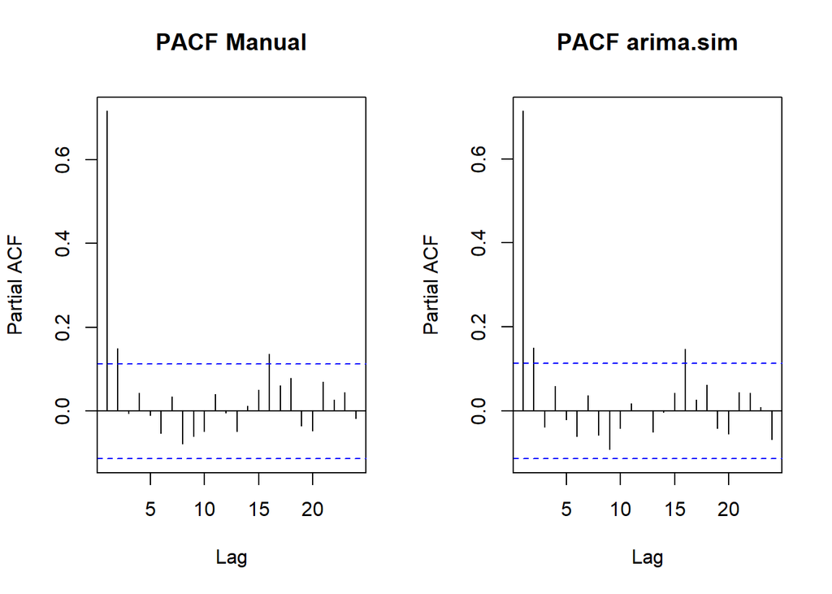

```r
par(mfrow = c(1, 2))
pacf(ar2, main = "PACF Manual")
pacf(ar2.sim, main = "PACF arima.sim")
```

```r
par(mfrow = c(1, 1))
```

**Interpretasi:** Berdasarkan plot PACF tersebut, terlihat bahwa PACF signifikan pada lag 1 kemudian *cuts off* (berada dalam batas signifikansi) setelah lag 2, sesuai dengan teori bahwa PACF proses AR(p) terputus setelah lag ke-p (p=2).

## Plot EACF

```r
TSA::eacf(ar2)
```

```
## AR/MA
##   0 1 2 3 4 5 6 7 8 9 10 11 12 13
## 0 x x x x x x x o o o o  o  o  o
## 1 x o o o o o o o o o o  o  o  o
## 2 o o o o o o o o o o o  o  o  o
## 3 x x o o o o o o o o o  o  o  o
## 4 x x o o o o o o o o o  o  o  o
## 5 x x o x o o x o o o o  o  o  o
## 6 x x x x o o o o o o o  o  o  o
## 7 x x x o x x o o o o o  o  o  o
```

```r
TSA::eacf(ar2.sim)
```

```
## AR/MA
##   0 1 2 3 4 5 6 7 8 9 10 11 12 13
## 0 x x x x x x x o o o o  o  o  o
## 1 x o o o o o o o o o o  o  o  o
## 2 x o o o o o o o o o o  o  o  o
## 3 x x o o o o o o o o o  o  o  o
## 4 x x o o o o o o o o o  o  o  o
## 5 x x x o o o o o o o o  o  o  o
## 6 x x x o o o o o o o o  o  o  o
## 7 x x x o x x o o o o o  o  o  o
```

## Scatterplot Yt vs Yt-1

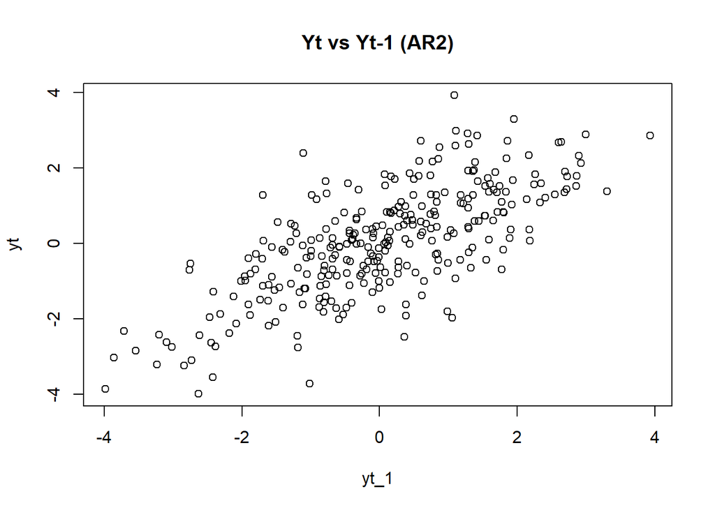

```r
yt   <- ar2[-1]
yt_1 <- ar2[-n]
plot(y = yt, x = yt_1, main = "Yt vs Yt-1 (AR2)")
```

```r
cor(yt, yt_1)
```

```
## [1] 0.7165728
```

**Interpretasi:** Berdasarkan scatterplot tersebut, terlihat bahwa terdapat hubungan positif yang cukup kuat antara $Y_t$ dengan $Y_{t-1}$ $(cor = 0.7166)$, mendekati autokorelasi teoritis $\rho_1 = 0.6250.$

## Scatterplot Yt vs Yt-2

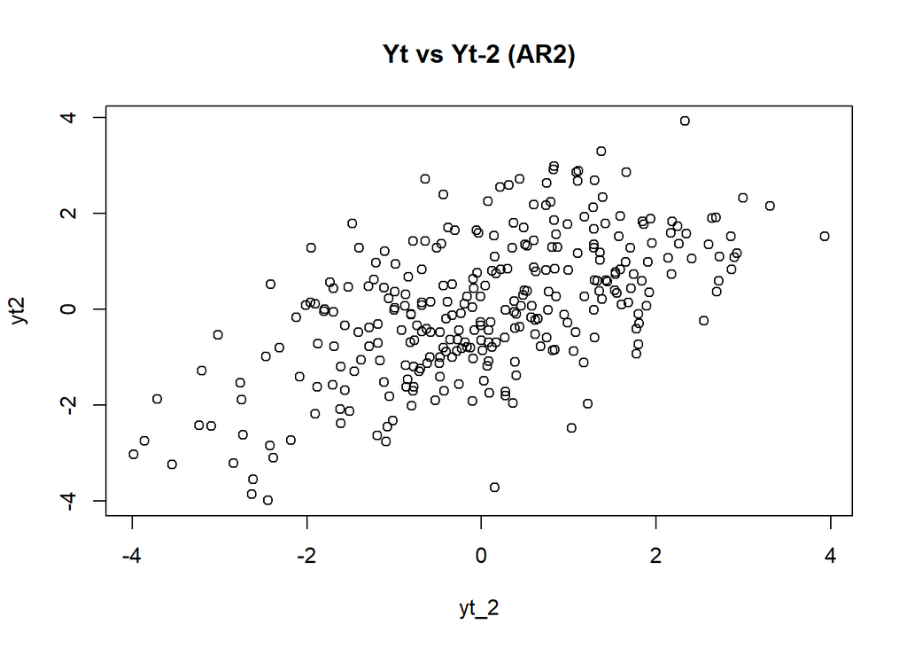

```r
yt2  <- ar2[-c(1,2)]
yt_2 <- ar2[-c(n-1, n)]
plot(y = yt2, x = yt_2, main = "Yt vs Yt-2 (AR2)")
```

```r
cor(yt2, yt_2)
```

```
## [1] 0.5856318
```

**Interpretasi:** Berdasarkan scatterplot tersebut, masih terlihat hubungan positif antara $Y_t$ dengan $Y_{t-2}$ $(cor = 0.5856)$, mendekati nilai teoritis $\rho_2 = 0.5125$.

## Scatterplot Yt vs Yt-3

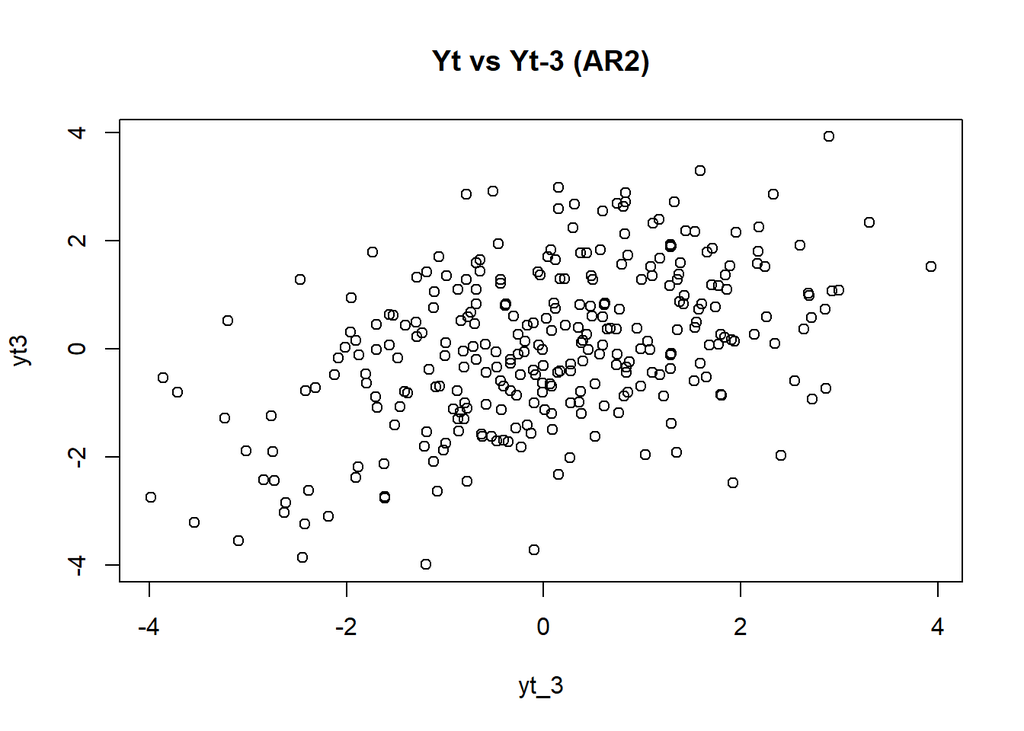

```r
yt3  <- ar2[-c(1,2,3)]
yt_3 <- ar2[-c(n-2, n-1, n)]
plot(y = yt3, x = yt_3, main = "Yt vs Yt-3 (AR2)")
```

```r
cor(yt3, yt_3)
```

```
## [1] 0.4609517
```

**Interpretasi:** Berdasarkan scatterplot tersebut, hubungan positif antara $Y_t$ dengan $Y_{t-3}$ masih terlihat meski melemah $(cor = 0.4610)$, mendekati nilai teoritis $\rho_3 = 0.3812$. Pola ini sesuai teori bahwa ACF proses AR meluruh secara perlahan (tidak langsung nol) seiring bertambahnya lag.

## Autokorelasi teoritis

```r
ARMAacf(ar = c(phi1, phi2), lag.max = 3)
```

```
##       0       1       2       3
## 1.00000 0.62500 0.51250 0.38125
```

# PROSES ARMA(2,2): theta1=0.4, theta2=0.6, phi1=0.5, phi2=0.2, n=300

```r
set.seed(1234)
n <- 300
wn <- rnorm(n)

phi1 <- 0.5
phi2 <- 0.2
theta1 <- 0.4
theta2 <- 0.6
```

## Pembangkitan manual

```r
arma22 <- wn[1:2]
for(i in 3:n){
  arma22[i] <- phi1*arma22[i-1] + phi2*arma22[i-2] +
               wn[i] + theta1*wn[i-1] + theta2*wn[i-2]
}
arma22
```

```
##   [1] -1.20706575  0.27742924  0.36847490 -1.50574039 -0.53766490 -1.29969338
##   [7] -0.87222246 -1.16894421 -1.88686532 -2.62101924 -2.85976172 -3.67737093
##  [13] -3.87256190 -3.51682974 -2.01340200 -1.39787953 -1.08104743 -2.00187014
##  [19] -2.72540011 -0.22882482 -0.06137315  0.93599896 -0.10064445  0.12583632
##  [25] -0.73142392 -1.79048404 -1.46228520 -2.75191579 -1.74816209 -2.98066156
##  [31] -1.12112807 -1.75293957 -1.33899414 -2.09047491 -3.56829700 -4.32225497
##  [37] -6.49933032 -7.02769676 -6.95242937 -6.26996504 -3.43890746 -3.74182948
##  [43] -2.97182019 -3.49823048 -3.96328734 -4.21591391 -4.99194239 -5.61517573
##  [49] -5.49498973 -5.32810275 -6.08211743 -5.70927767 -6.49640107 -6.19781948
##  [55] -5.63181806 -4.16631812 -1.43386859 -1.32659086  1.33518960 -0.57718012
##  [61]  1.13545868  2.56923464  2.89049817  2.80495292  1.68426167  2.77538382
##  [67]  1.29220743  3.17981523  3.04188012  3.84589813  3.47054592  2.25362466
##  [73]  1.27634579  1.31729358  3.02358708  2.83893413  1.81428668  0.10302896
##  [79] -0.45121970 -0.85290753 -0.66635425 -0.93510416 -2.14779642 -2.08562341
##  [85] -1.51503473 -0.24121274  0.91556687  0.64537308  0.48311177 -1.14217407
```

[output cut: 35 more lines]

## Pembangkitan dengan arima.sim

```r
set.seed(1234)
arma22.sim <- arima.sim(list(order=c(2,0,2), ar=c(phi1,phi2), ma=c(theta1,theta2)), n=n)
arma22.sim
```

```
## Time Series:
## Start = 1
## End = 300
## Frequency = 1
##   [1] -2.75189059 -1.74814288 -2.98064692 -1.12111691 -1.75293106 -1.33898765
##   [7] -2.09046996 -3.56829323 -4.32225209 -6.49932813 -7.02769509 -6.95242810
##  [13] -6.26996407 -3.43890672 -3.74182891 -2.97181976 -3.49823015 -3.96328709
##  [19] -4.21591372 -4.99194225 -5.61517562 -5.49498965 -5.32810268 -6.08211738
##  [25] -5.70927763 -6.49640104 -6.19781946 -5.63181804 -4.16631811 -1.43386858
##  [31] -1.32659085  1.33518960 -0.57718012  1.13545868  2.56923465  2.89049818
##  [37]  2.80495292  1.68426168  2.77538382  1.29220743  3.17981524  3.04188012
##  [43]  3.84589813  3.47054592  2.25362466  1.27634579  1.31729358  3.02358708
##  [49]  2.83893413  1.81428668  0.10302896 -0.45121970 -0.85290753 -0.66635425
##  [55] -0.93510416 -2.14779642 -2.08562341 -1.51503473 -0.24121274  0.91556687
##  [61]  0.64537308  0.48311177 -1.14217407 -1.12039092 -1.27141453  0.91636167
```

[output cut: 39 more lines]

## Plot time series

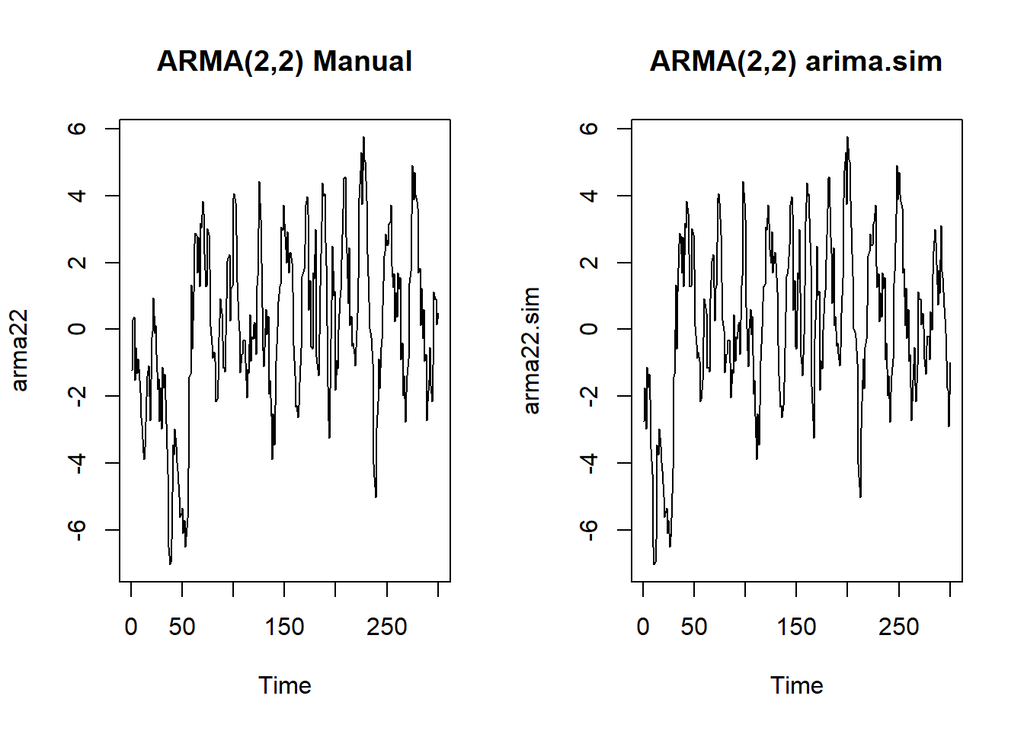

```r
par(mfrow = c(1, 2))
ts.plot(arma22, main = "ARMA(2,2) Manual")
ts.plot(arma22.sim, main = "ARMA(2,2) arima.sim")
```

```r
par(mfrow = c(1, 1))
```

**Interpretasi:** Berdasarkan plot time series, terlihat bahwa data ARMA(2,2) hasil pembangkitan manual maupun `arima.sim` berfluktuasi di sekitar rataan konstan tanpa tren, sehingga data tersebut stasioner dalam rataan.

## Plot ACF

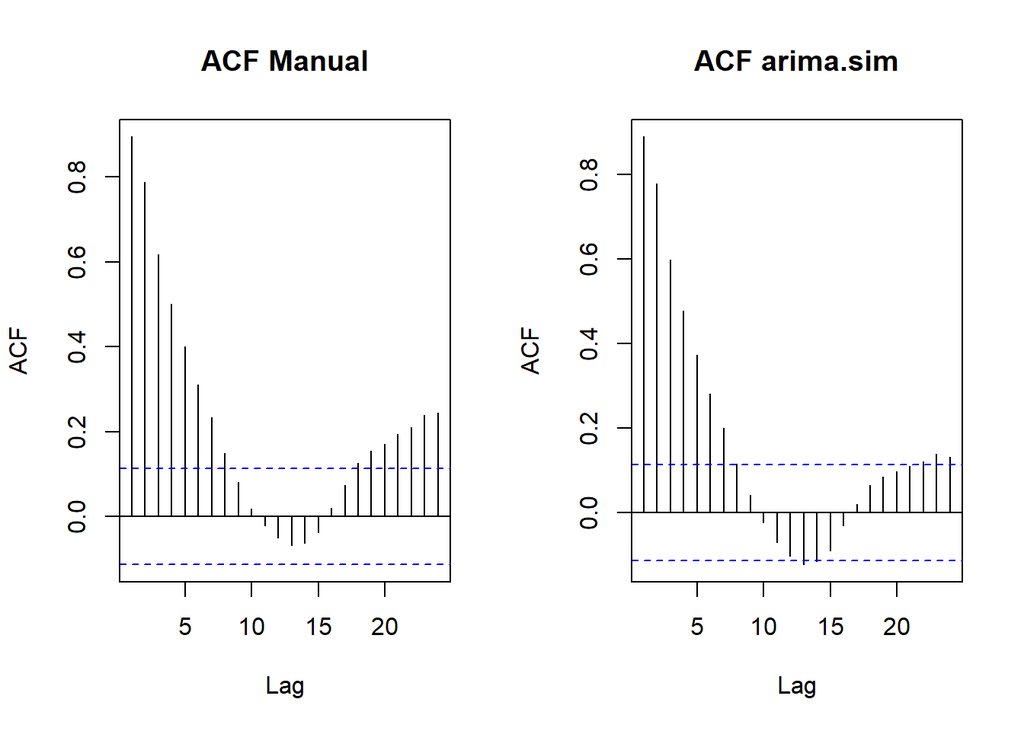

```r
par(mfrow = c(1, 2))
acf(arma22, main = "ACF Manual")
acf(arma22.sim, main = "ACF arima.sim")
```

```r
par(mfrow = c(1, 1))
```

**Interpretasi:** Berdasarkan plot ACF tersebut, terlihat bahwa ACF meluruh *(tails off)* secara eksponensial dan tidak terputus tegas pada lag tertentu, sebagaimana ciri khas proses campuran ARMA.

## Plot PACF

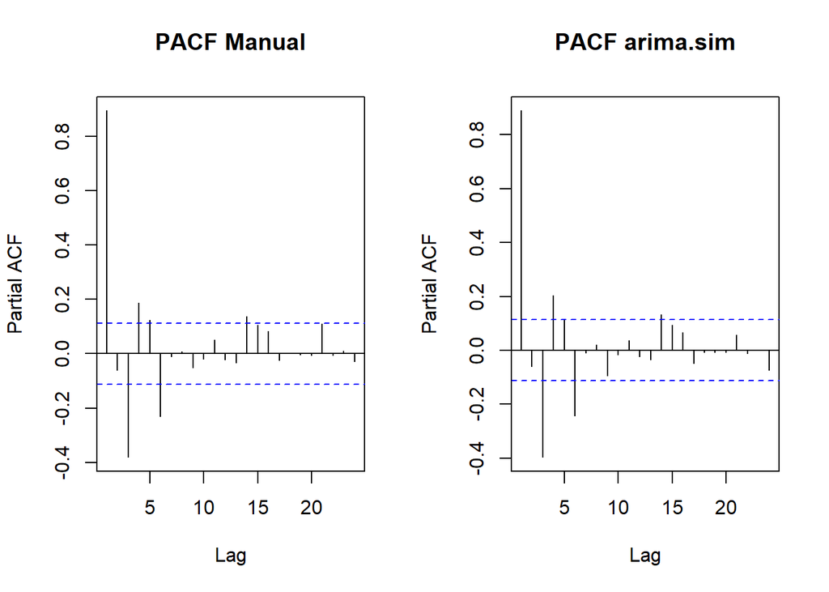

```r
par(mfrow = c(1, 2))
pacf(arma22, main = "PACF Manual")
pacf(arma22.sim, main = "PACF arima.sim")
```

```r
par(mfrow = c(1, 1))
```

**Interpretasi:** Berdasarkan plot PACF tersebut, terlihat bahwa PACF juga cenderung *tails off* dengan pola bergelombang, tidak terputus tegas pada lag tertentu, sebagaimana ciri khas proses campuran ARMA.

## Plot EACF

```r
TSA::eacf(arma22)
```

```
## AR/MA
##   0 1 2 3 4 5 6 7 8 9 10 11 12 13
## 0 x x x x x x x x o o o  o  o  o
## 1 o x o o o o x o o o o  o  o  o
## 2 x x o o o o x o o o o  o  o  o
## 3 x x o x o o x o o o o  o  o  o
## 4 x x x x o o x o o o o  o  o  o
## 5 x x x x x x x o o o o  o  o  o
## 6 o o x o x x o o o o o  o  o  o
## 7 o o x o x x o x o o o  o  o  o
```

```r
TSA::eacf(arma22.sim)
```

```
## AR/MA
##   0 1 2 3 4 5 6 7 8 9 10 11 12 13
## 0 x x x x x x x o o o o  o  x  o
## 1 o x o o o o x o o o o  o  o  o
## 2 x x o o o o o o o o o  o  o  o
## 3 x x x x o o o o o o o  o  o  o
## 4 x x x x o o o o o o o  o  o  o
## 5 x x x x x x x o o o o  o  o  o
## 6 o o x o x x o o o o o  o  o  o
## 7 x o x x x x o x o o o  o  o  o
```

**Interpretasi:** Berdasarkan pola segitiga nol pada plot EACF, segitiga nol mulai terbentuk pada ordo AR(2) dan MA(2), yang sesuai dengan model ARMA(2,2) yang dibangkitkan.

## Scatterplot Yt vs Yt-1

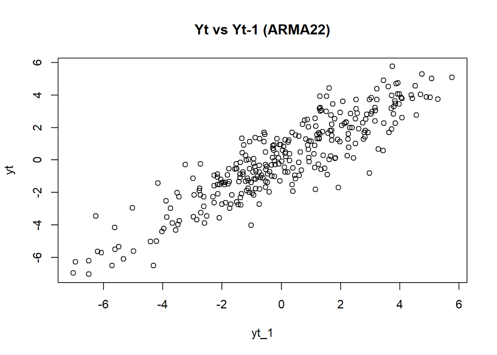

```r
yt   <- arma22[-1]
yt_1 <- arma22[-n]
plot(y = yt, x = yt_1, main = "Yt vs Yt-1 (ARMA22)")
```

```r
cor(yt, yt_1)
```

```
## [1] 0.8946787
```

**Interpretasi:** Berdasarkan scatterplot tersebut, terlihat bahwa terdapat hubungan positif yang kuat antara $Y_t$ dengan $Y_{t-1}$ $(cor = 0.8947)$, mendekati autokorelasi teoritis $\rho_1 = 0.8592$.

## Scatterplot Yt vs Yt-2

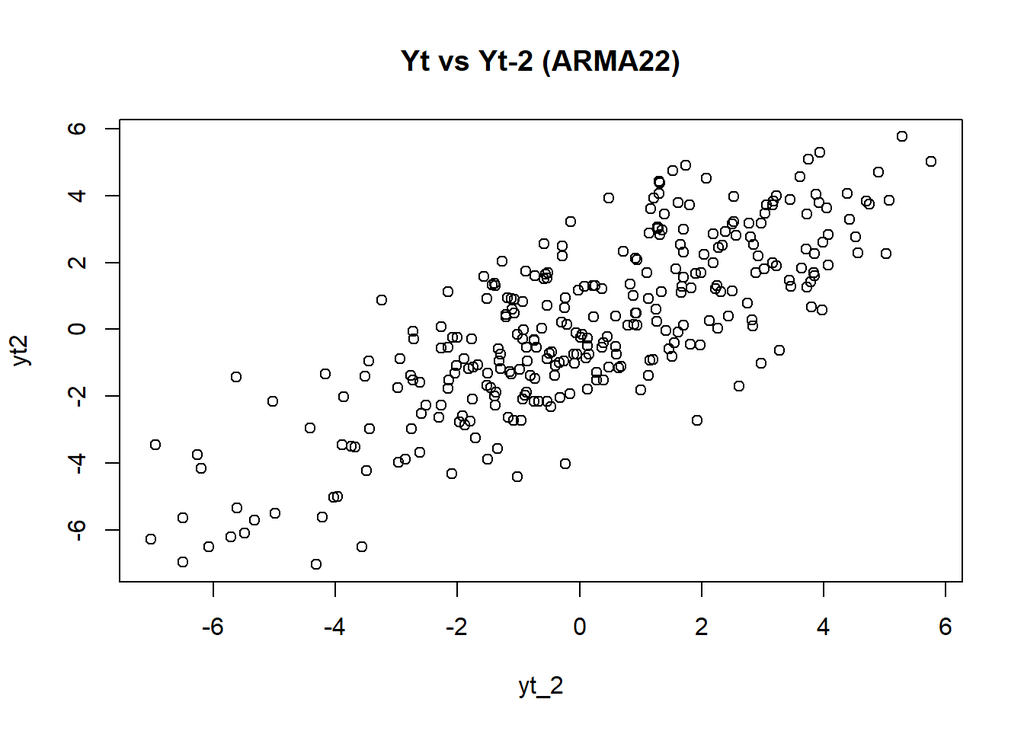

```r
yt2  <- arma22[-c(1,2)]
yt_2 <- arma22[-c(n-1, n)]
plot(y = yt2, x = yt_2, main = "Yt vs Yt-2 (ARMA22)")
```

```r
cor(yt2, yt_2)
```

```
## [1] 0.78822
```

**Interpretasi:** Berdasarkan scatterplot tersebut, hubungan positif masih terlihat kuat antara $Y_t$ dengan $Y_{t-2}$ $(cor = 0.7882)$, mendekati nilai teoritis $\rho_2 = 0.7492$.

## Scatterplot Yt vs Yt-3

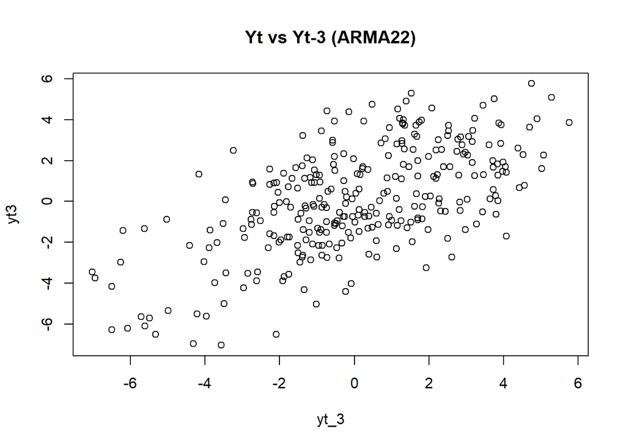

```r
yt3  <- arma22[-c(1,2,3)]
yt_3 <- arma22[-c(n-2, n-1, n)]
plot(y = yt3, x = yt_3, main = "Yt vs Yt-3 (ARMA22)")
```

```r
cor(yt3, yt_3)
```

```
## [1] 0.6177423
```

**Interpolasi:** Berdasarkan scatterplot tersebut, hubungan positif antara $Y_t$ dengan $Y_{t-3}$ masih terlihat meski mulai melemah $(cor = 0.6177)$, mendekati nilai teoritis $\rho_3 = 0.5464$. Pola ini sesuai teori bahwa ACF proses ARMA meluruh secara perlahan mengikuti komponen AR-nya, sama seperti pada proses AR(2) sebelumnya.

## Autokorelasi teoritis

```r
ARMAacf(ar = c(phi1, phi2), ma = c(theta1, theta2), lag.max = 3)
```

```
##         0         1         2         3
## 1.0000000 0.8591993 0.7491908 0.5464353
```